# Missing Data Approaches

### Is there a pattern to missing values?

- Let’s visualize predictor distributions in records WITH ozone measurements
- First, subset data into two different data frames for plotting: one with zero missing Y measurements, the other only containing missing Y

```r
aq_data <- airquality
aq_data$time <- as.numeric(paste0(aq_data$Month + aq_data$Day)) # for quick plotting by time
present_data <- filter(aq_data, is.na(Ozone)==FALSE)
missing_data <- filter(aq_data, is.na(Ozone)==TRUE)
```

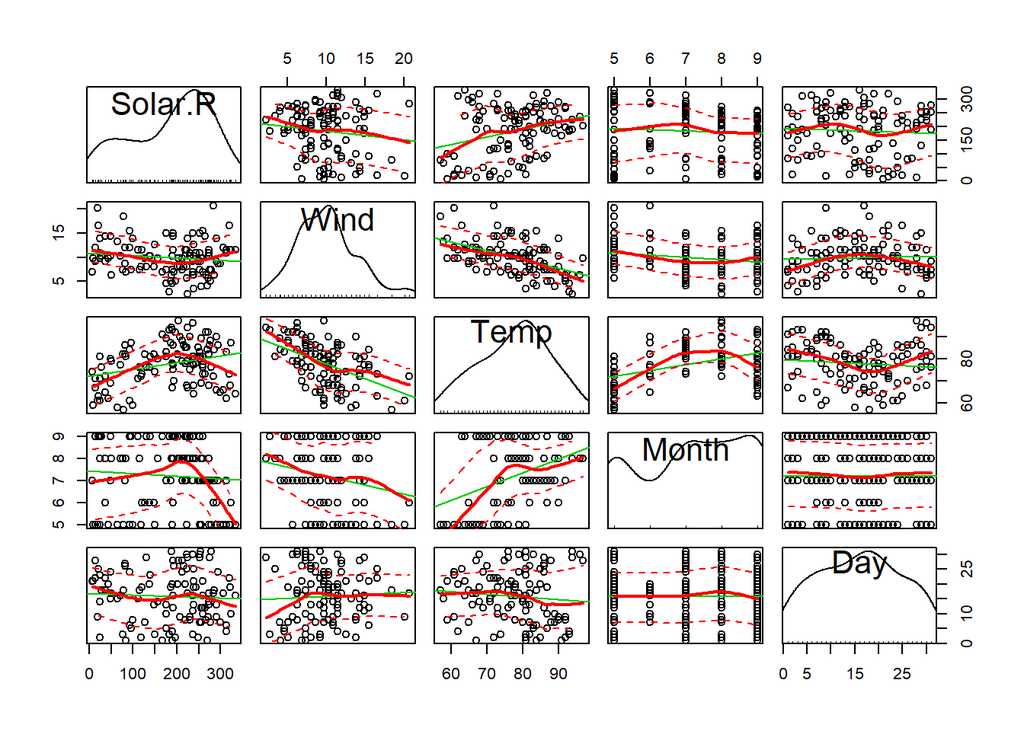

```r
## Records with Ozone measurements
car::scatterplotMatrix( ~ Solar.R + Wind + Temp + Month + Day, data = present_data)
```

- Now visualize predictor distributions in records WITHOUT ozone measurements, are there any visual differences between these two sub-sets?

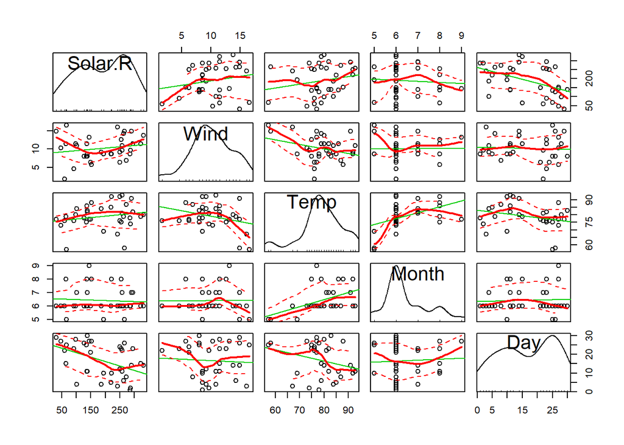

```r
# records missing Ozone measurements
car::scatterplotMatrix( ~ Solar.R + Wind + Temp + Month + Day, data = missing_data)
```

- This second subset appears to have quite a few missing values in Month 6
- What would be a more alarming visual cue for measurement bias?
- What if a predictor variable is highly correlated with missingness instead?

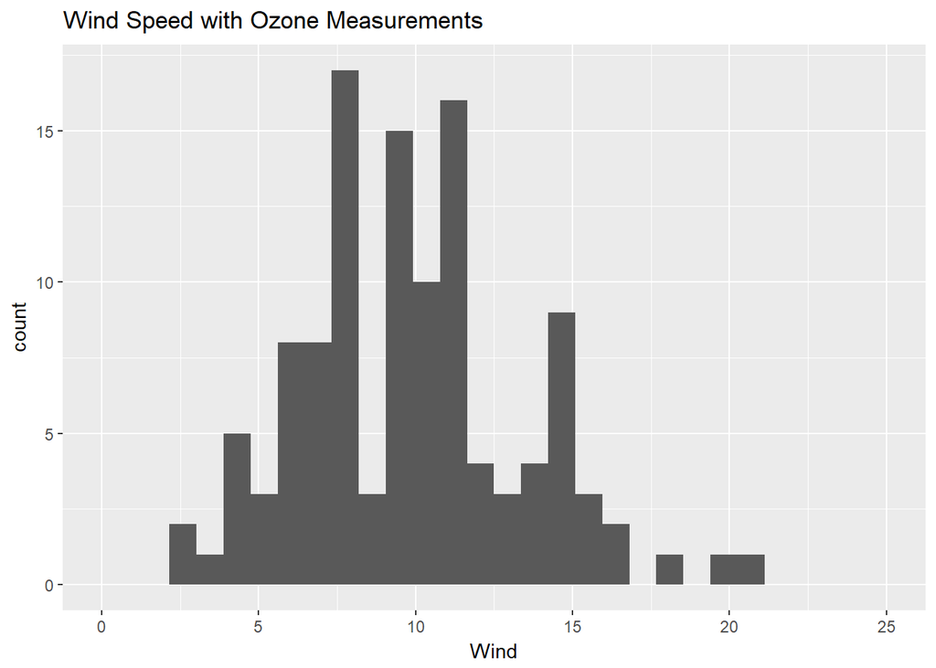

```r
## Subset to missing ozone measurements
fishy <- filter(airquality, is.na(Ozone)==TRUE)
## create random wind speeds twice the mean
fishy$Wind <- rpois(n = nrow(fishy), lambda = mean(airquality$Wind)*2)

ggplot(present_data, aes(Wind)) + geom_histogram() + scale_x_continuous(limits = c(0, 25)) + ggtitle("Wind Speed with Ozone Measurements")
```

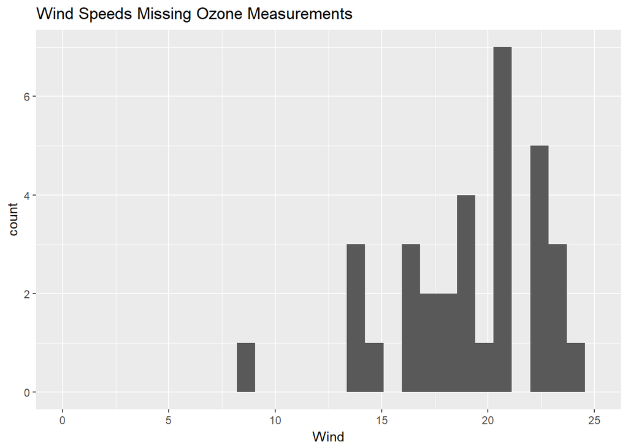

```r
ggplot(fishy, aes(Wind)) + geom_histogram() + scale_x_continuous(limits = c(0, 25)) + ggtitle("Wind Speeds Missing Ozone Measurements")
```

- Here we see there is a clear pattern of missingness